← Eğitim Listesine Geri Dön

# İki Örneklem Oran Testi

2025-06-09

oran testi Z-testi kategorik veri

# 📊 İki Örneklem Oran Testi: Kategorik Farkları Sayılarla Sınamak

## Giriş: Hangi Tasarım Daha İyi?

Diyelim ki iki farklı web sitesi tasarımı var.  
Birisi eski versiyon → diğeriyse yeni versiyon.  
Her tasarımda 1000 kişiye gösterildi.  
Yeni tasarım %15 tıklama oranı sundu, eski tasarım %12.

Peki bu fark gerçekten anlamlı mı?

## 🔍 İki Örneklem Oran Testi Nedir?

Bu test, **iki bağımsız gruptaki oranların farklı olup olmadığını** test eder.

📌 Genellikle:

- Dönüşüm oranları
- Tıklama oranları
- Memnuniyet oranları
- Sağlık sonuçları

📌 Bu testte kullandığımız dağılım: **normal dağılım (Z-testi)**  
Çünkü büyük örneklemde çalışıyoruz ve binom yerine normal yaklaşım kullanıyoruz.

## 📐 Formülü:

$$ z = \frac{p_1 - p_2}{\sqrt{\hat{p}(1 - \hat{p})\left(\frac{1}{n_1} + \frac{1}{n_2}\right)}} $$

| Sembol | Açıklama |
| --- | --- |
| $p_1$ | Grup 1 oranı |
| $p_2$ | Grup 2 oranı |
| $\hat{p}$ | Birleştirilmiş oran = `(x₁ + x₂) / (n₁ + n₂)` |
| $n_1, n_2$ | Her grup için örneklem sayısı |

📌 Eğer `|z| > 1.96` ve `p < 0.05` → H₀ reddedilir

# İki Örneklem Oran Testi

İki örneklem oran testi, iki farklı popülasyondan alınan iki bağımsız örneklemdeki belirli bir özelliğin oranlarını karşılaştırmak için kullanılan bir hipotez testidir. Temel amaç, iki popülasyon arasındaki oranlar arasında istatistiksel olarak anlamlı bir fark olup olmadığını belirlemektir. Örneğin, iki farklı şehirdeki insanların belirli bir ürünü tercih etme oranlarını karşılaştırmak için bu test kullanılabilir.

**İki Örneklem Oran Testinin Temel Kavramları:**

- **Popülasyon:** İncelenen tüm bireylerin veya nesnelerin oluşturduğu gruptur.
- **Örneklem:** Popülasyondan seçilen ve üzerinde çalışma yapılan daha küçük bir gruptur.
- **Oran (p):** Bir örneklemde belirli bir özelliğe sahip olan bireylerin sayısının toplam birey sayısına oranıdır.
- **Sıfır Hipotezi (H₀):** İki popülasyon oranının eşit olduğunu varsayan hipotezdir (p₁ = p₂).
- **Alternatif Hipotez (H₁ veya Hₐ):** İki popülasyon oranının eşit olmadığını (p₁ ≠ p₂), birinin diğerinden büyük (p₁ > p₂) veya küçük (p₁ < p₂) olduğunu varsayan hipotezdir.

Varsayımlarımız:

n1>30

n2>30

n 30'dan büyük olduğunda z'yi kullanarak bir oran testi gerçekleştirebiliyoruz.

**İki Örneklem Oran Testi Nasıl Yapılır?**

İki örneklem oran testi genellikle z-testi kullanılarak gerçekleştirilir. Testin adımları şunlardır:

1. **Hipotezleri Belirleyin:** Sıfır hipotezi (H₀: p₁ = p₂) ve alternatif hipotezi (örneğin, H₁: p₁ ≠ p₂) formüle edin.
2. **Anlamlılık Düzeyini (α) Seçin:** Genellikle 0.05 (yani %5) olarak seçilir. Bu, sıfır hipotezi doğruyken onu reddetme olasılığını temsil eder.
3. **Örneklem Oranlarını Hesaplayın:** Her iki örneklem için de oranları (p₁ ve p₂) hesaplayın.
4. **Birleştirilmiş Oranı (p̂) Hesaplayın:** İki örneklemdeki toplam başarılı vaka sayısını toplam örneklem sayısına bölerek birleştirilmiş oranı hesaplayın.

   p̂ = (x₁ + x₂) / (n₁ + n₂)

   Burada:
   - x₁ ve x₂: Her iki örneklemdeki başarılı vaka sayıları
   - n₁ ve n₂: Her iki örneklemdeki toplam birey sayıları
5. **Test İstatistiğini (z) Hesaplayın:** Aşağıdaki formülü kullanarak z test istatistiğini hesaplayın:

   z = (p₁ - p₂) / √[p̂(1 - p̂)(1/n₁ + 1/n₂)]
6. **Kritik Değeri veya p-Değerini Bulun:** Seçilen anlamlılık düzeyine (α) ve alternatif hipotezin yönüne (tek yönlü veya çift yönlü) bağlı olarak z tablosundan kritik değeri bulun veya test istatistiğine karşılık gelen p-değerini hesaplayın.
7. **Karar Verin:**
   - **Kritik Değer Yaklaşımı:** Hesaplanan z test istatistiğinin mutlak değeri, kritik değerden büyükse, sıfır hipotezi reddedilir.
   - **p-Değeri Yaklaşımı:** p-değeri anlamlılık düzeyinden (α) küçükse, sıfır hipotezi reddedilir.

## 🧠 Neden Önemlidir?

| Sebep | Açıklama |
| --- | --- |
| ✅ **Kategorik veride karar verme** | Evet/hayır, başarılı/başarısız gibi durumlarda |
| ✅ **A/B testlerinde yön verir** | Yeni tasarım daha iyi mi? Yoksa eski mi? |
| ✅ **Modelleme sürecinde kullanılır** | Kullanıcı davranışlarını analiz etmede |
| ✅ **Etki ölçümü yapmak için** | Oransal değişimi sayılarla ifade etmek için |

📌 Bu test sayesinde:

- Farkı yakalarsın,
- Anlamlılığını sınarsın,
- Karar verirsin.

## 🛠️ Adım Adım Uygulama: Gerçek Hayat Senaryosu

Ne demiştik, iki farklı web sitesi tasarımı var.  
Birisi eski versiyon → diğeriyse yeni versiyon.  
Her tasarımda 1000 kişiye gösterildi.  
Yeni tasarım %15 tıklama oranı sundu, eski tasarım %12.

Peki bu fark gerçekten anlamlı mı?

### Örnek:

- **Grup A:** Eski tasarım → 1000 kişi, 120 dönüşüm → `%12`
- **Grup B:** Yeni tasarım → 1000 kişi, 150 dönüşüm → `%15`

#### Soru:

“Yeni tasarım gerçekten daha mı iyi?”

### Adım 1: Hipotez Kurulumu

```
print("H₀: p_A = p_B → Fark yok")
print("H₁: p_A ≠ p_B → Fark var")
```

✅ Null hipotezi → fark yok  
Alternatif → fark var

### Adım 2: Anlamlılık Düzeyini Ayarla

```python
alpha = 0.05
print(f"Anlamlılık düzeyi (α): {alpha}")
```

```
Anlamlılık düzeyi (α): 0.05
```

📌 %5 yanılma payı kabul ettik.

### Adım 3: Sample Veri Üret

```python
import numpy as np

np.random.seed(42)
n_A = 1000
n_B = 1000

# Simülasyon: başarı sayıları
x_A = 120
x_B = 150

print(f"Grup A: {x_A}/{n_A} → %{x_A/n_A*100:.2f}")
print(f"Grup B: {x_B}/{n_B} → %{x_B/n_B*100:.2f}")
```

```
Grup A: 120/1000 → %12.00
Grup B: 150/1000 → %15.00
```

### Adım 4: Z-Testi Yap

```python
from statsmodels.stats.proportion import proportions_ztest

count = [x_A, x_B]
nobs = [n_A, n_B]

z_skoru, p_degeri = proportions_ztest(count, nobs, alternative='two-sided')
p_hat = (x_A + x_B) / (n_A + n_B)
print(f"Z Skoru: {z_skoru:.2f}, p-değeri: {p_degeri:.4f}")
```

```
Z Skoru: -1.96, p-değeri: 0.0496
```

### Adım 5: Karar Ver

```python
if p_degeri < alpha:
    print("✅ H₀ reddedildi → Fark var")
else:
    print("❌ H₀ reddedilemedi → Fark tesadüfi olabilir")
```

```
✅ H₀ reddedildi → Fark var
```

📌 Yani: Yeni tasarım istatistiksel olarak daha iyi

## 📈 Görselleştirme: Oranlar Nasıl Değişiyor?

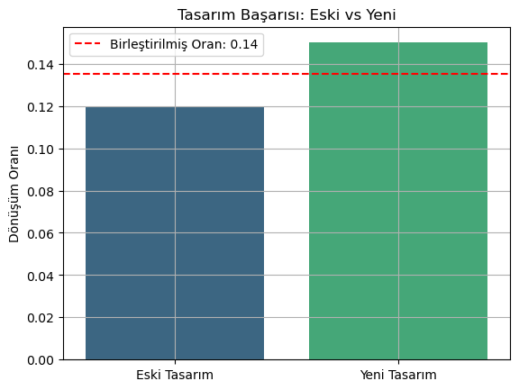

```python
import matplotlib.pyplot as plt
import seaborn as sns


oranlar = [x_A/n_A, x_B/n_B]
gruplar = ['Eski Tasarım', 'Yeni Tasarım']

sns.barplot(x=gruplar, y=oranlar,hue=gruplar, palette="viridis")
plt.axhline(y=p_hat, color='red', linestyle='--', label=f'Birleştirilmiş Oran: {p_hat:.2f}')
plt.title("Tasarım Başarısı: Eski vs Yeni")
plt.ylabel("Dönüşüm Oranı")
plt.legend()
plt.grid(True)
plt.show()
```

📌 Bu grafikte:

- Her tasarımın oranı
- Ortak oran çizgisi

## 📉 Varsayımlar Ne?

| Varsayım | Açıklama |
| --- | --- |
| **Bağımsızlık** | Her iki grubun da bireyleri birbirinden bağımsız olmalı |
| **Büyük örneklem** | n ≥ 30 önerilir |
| **Başarı sayısı yeterli mi?** | n * p ≥ 10, n * (1-p) ≥ 10 olmalı |

📌 Bu varsayımlar sağlanmazsa → Fisher Exact Test veya Binom Testi düşünülmeli

**Örnek:**

İki farklı şehirde (A ve B) yaşayan insanların belirli bir markayı tercih etme oranlarını karşılaştırmak istiyoruz. Şehir A'dan 100 kişi örneklenmiş ve 60'ının bu markayı tercih ettiği bulunmuştur. Şehir B'den ise 150 kişi örneklenmiş ve 75'inin bu markayı tercih ettiği bulunmuştur. Anlamlılık düzeyi α = 0.05 olsun.

```python
#İki Örneklem Oran Testi (Two-Proportion Z-Test) Python Kodu

import numpy as np
from statsmodels.stats.proportion import proportions_ztest
import scipy.stats as stats

# Verilerin tanımlanması
n1 = 100  # Şehir A örneklem büyüklüğü
count1 = 60  # Şehir A'daki tercih sayısı

n2 = 150  # Şehir B örneklem büyüklüğü
count2 = 75  # Şehir B'deki tercih sayısı

alpha = 0.05  # Anlamlılık düzeyi

# 1. Hipotezler
print("Hipotezler:")
print("H₀: pₐ = pʙ (İki şehir arasında tercih oranı farkı yoktur)")
print("H₁: pₐ ≠ pʙ (İki şehir arasında tercih oranı farkı vardır)\n")
```

```
Hipotezler:
H₀: pₐ = pʙ (İki şehir arasında tercih oranı farkı yoktur)
H₁: pₐ ≠ pʙ (İki şehir arasında tercih oranı farkı vardır)
```

```python
# 2. Örneklem oranlarının hesaplanması
p1 = count1 / n1
p2 = count2 / n2
print(f"Şehir A Tercih Oranı: {p1:.2f} ({count1}/{n1})")
print(f"Şehir B Tercih Oranı: {p2:.2f} ({count2}/{n2})")
```

```
Şehir A Tercih Oranı: 0.60 (60/100)
Şehir B Tercih Oranı: 0.50 (75/150)
```

```python
# 3. İki oran testi (proportions_ztest)
count = np.array([count1, count2])  # Başarı sayıları
nobs = np.array([n1, n2])          # Gözlem sayıları

# Alternatif seçenekler: 'two-sided', 'smaller', 'larger'
z_stat, p_value = proportions_ztest(count, nobs, alternative='two-sided')
```

```python
# 4. Kritik değerin hesaplanması
z_critical = stats.norm.ppf(1 - alpha/2)  # Çift yönlü test
print(f"\nTest İstatistiği (z): {z_stat:.4f}")
print(f"Kritik z Değeri (±): {z_critical:.4f}")
print(f"p-değeri: {p_value:.6f}")
```

```
Test İstatistiği (z): 1.5542
Kritik z Değeri (±): 1.9600
p-değeri: 0.120143
```

```python
# 5. Karar kuralı
if abs(z_stat) > z_critical:
    print("\n✅ SONUÇ: |z| > kritik değer → H₀ REDDEDİLİR")
    print("İki şehir arasında istatistiksel olarak anlamlı bir fark vardır.")

    # Hangi şehirde oran daha yüksek?
    if p1 > p2:
        print(f"→ Şehir A'nın tercih oranı ({p1:.2%}), Şehir B'den ({p2:.2%}) anlamlı şekilde yüksektir")
    else:
        print(f"→ Şehir B'nin tercih oranı ({p2:.2%}), Şehir A'dan ({p1:.2%}) anlamlı şekilde yüksektir")
else:
    print("\n❌ SONUÇ: |z| ≤ kritik değer → H₀ REDDEDİLEMEZ")
    print("İki şehir arasında istatistiksel olarak anlamlı bir fark yoktur.")
```

```
❌ SONUÇ: |z| ≤ kritik değer → H₀ REDDEDİLEMEZ
İki şehir arasında istatistiksel olarak anlamlı bir fark yoktur.
```

```python
# 6. Ek bilgiler
pooled_prop = (count1 + count2) / (n1 + n2)
print(f"\nBirleştirilmiş Oran (p̂): {pooled_prop:.4f}")
```

```
Birleştirilmiş Oran (p̂): 0.5400
```

```python
# 7. Güven aralıkları
# Şehir A için güven aralığı
se1 = np.sqrt(p1*(1-p1)/n1)
ci1_low, ci1_high = p1 - z_critical*se1, p1 + z_critical*se1

# Şehir B için güven aralığı
se2 = np.sqrt(p2*(1-p2)/n2)
ci2_low, ci2_high = p2 - z_critical*se2, p2 + z_critical*se2

print(f"\nŞehir A için %95 Güven Aralığı: ({ci1_low:.4f}, {ci1_high:.4f})")
print(f"Şehir B için %95 Güven Aralığı: ({ci2_low:.4f}, {ci2_high:.4f})")
```

```
Şehir A için %95 Güven Aralığı: (0.5040, 0.6960)
Şehir B için %95 Güven Aralığı: (0.4200, 0.5800)
```

```python
# 8. Etki büyüklüğü (Risk Farkı ve NNT)
risk_difference = p1 - p2
nnt = 1 / risk_difference if risk_difference != 0 else np.inf  # Number Needed to Treat

print(f"\nRisk Farkı (pₐ - pʙ): {risk_difference:.4f}")
if abs(risk_difference) > 0:
    print(f"Etkiyi görmek için gereken minimum kişi sayısı (NNT): {abs(nnt):.1f}")
```

```
Risk Farkı (pₐ - pʙ): 0.1000
Etkiyi görmek için gereken minimum kişi sayısı (NNT): 10.0
```

Kodu kendi verilerinize uygulamak için n1, count1, n2 ve count2 değişkenlerini güncelleyebilirsiniz. Tek yönlü test yapmak isterseniz alternative parametresini 'smaller' veya 'larger' olarak değiştirebilirsiniz.

## 📊 Gerçek Hayatta Kullanım Alanları

| Senaryo | Açıklama |
| --- | --- |
| Web tasarımı | Yeni buton mu eski buton mu daha iyi? |
| Pazarlama | Kampanya A mı B mi daha yüksek dönüşüm verdi? |
| Ürün testi | Yeni ürün daha fazla memnuniyet yaratıyor mu? |
| Finans | Yatırım stratejisi A mı B mi daha iyi getiri sağlıyor? |

📌 Süreç:

1. Hipotez kur
2. Veri topla
3. Test yap
4. p-değeri ile karar ver

İki örneklem oran testi için kullanılan test istatistiği genellikle z oranıdır. İki bağımsız grup arasında oranların karşılaştırılması için kullanılan z oranının formülünü ve nasıl yapılır tekrar gösterelim:

## $z = \frac{(\hat{p}_1 - \hat{p}_2)}{\sqrt{p_{pooled} \cdot (1 - p_{pooled}) \left(\frac{1}{n_1} + \frac{1}{n_2}\right)}} $

Burada:

- $ \hat{p}_1$ ve $\hat{p}_2 $: Sırasıyla Grup 1 ve Grup 2'nin gözlemlenen oranları
- $p_{pooled}$: Grup 1 ve Grup 2'nin birleştirilmiş (pooled) oranı, $p_{pooled} = \frac{X_1 + X_2}{n_1 + n_2}$
- $n_1$ ve $n_2$: Sırasıyla Grup 1 ve Grup 2'nin örnekleme büyüklükleri

Bu test istatistiği, iki bağımsız grup arasında oranların farklı olup olmadığını değerlendirmek için kullanılır. Z istatistiği daha sonra z-tablosu veya istatistiksel yazılım kullanılarak belirli bir anlamlılık düzeyinde (genellikle 0.05) kritik değerle karşılaştırılır.

H0 (null hypothesis) hipotezi genellikle "Grup 1 ve Grup 2 arasında oranlar arasında bir fark yoktur" şeklinde ifade edilir. Eğer test sonucu H0 hipotezini reddediyorsa, bu gruplar arasında oranlarda istatistiksel olarak anlamlı bir fark olduğu sonucuna varılabilir.

A/B testi genellikle şu adımları içerir:

1. **Hipotezlerin Belirlenmesi:**
- **Null Hypothesis (H0):** Gruplar arasında bir fark yoktur.
- **Alternative Hypothesis (H1):** Gruplar arasında anlamlı bir fark vardır.
2. **Veri Toplama:**
- Kontrol grubu (Grup A) ve deneme grubu (Grup B) oluşturulur.
- Her iki gruptan örneklem verileri toplanır.
3. **İstatistiksel Test Uygulama:**
- İki grup arasındaki oranlar karşılaştırılır.
- İki oran arasındaki farkın istatistiksel olarak anlamlı olup olmadığını belirlemek için bir test uygulanır. Bu genellikle z-testi veya chi-kare testi gibi yöntemleri içerebilir.
4. **Anlamlılık Seviyesi ve Güven Aralıkları:**
- Belirli bir anlamlılık düzeyinde (örneğin, %5) hipotez testi yapılır.
- Güven aralıkları hesaplanabilir.
5. **Sonuçların Değerlendirilmesi:**
- Elde edilen p değeri (anlamlılık düzeyi), H0'ı reddetmek veya kabul etmek için kullanılır.
- Eğer p değeri belirli bir anlamlılık düzeyinden küçükse (genellikle 0.05), H0 reddedilir ve gruplar arasında anlamlı bir fark olduğu sonucuna varılır.

İki Örneklem Oran Testi, kullanıcı davranışları, dönüşüm oranları, tıklama oranları gibi oransal ölçümleri karşılaştırarak değişikliklerin etkilerini değerlendirmek için yaygın olarak kullanılır.

Kullanım Alanlarına Örnekler:

1. **Pazarlama:**
- Problem: İki farklı reklam stratejisinin etkinliğini değerlendirmek istiyorsunuz.
- Uygulama: İki farklı reklam stratejisinin kullanıldığı iki farklı örneklemde, her bir stratejinin tıklama oranlarını karşılaştırabilirsiniz.

```python
# İki Farklı Reklam Stratejisinin Tıklama Oranlarının Karşılaştırılması

import numpy as np
from statsmodels.stats.proportion import proportions_ztest
import scipy.stats as stats
import matplotlib.pyplot as plt

## 1. Veri Hazırlama ve Tanımlayıcı İstatistikler
# Strateji A: 1000 gösterimde 120 tıklama
# Strateji B: 1100 gösterimde 150 tıklama
n_strategy_a = 1000
clicks_strategy_a = 120

n_strategy_b = 1100
clicks_strategy_b = 150

# Oranları hesapla
p_a = clicks_strategy_a / n_strategy_a
p_b = clicks_strategy_b / n_strategy_b

print("=== Reklam Stratejileri Performans Karşılaştırması ===")
print(f"Strateji A: {clicks_strategy_a}/{n_strategy_a} (Tıklama Oranı: {p_a:.2%})")
print(f"Strateji B: {clicks_strategy_b}/{n_strategy_b} (Tıklama Oranı: {p_b:.2%})\n")
```

```
=== Reklam Stratejileri Performans Karşılaştırması ===
Strateji A: 120/1000 (Tıklama Oranı: 12.00%)
Strateji B: 150/1100 (Tıklama Oranı: 13.64%)
```

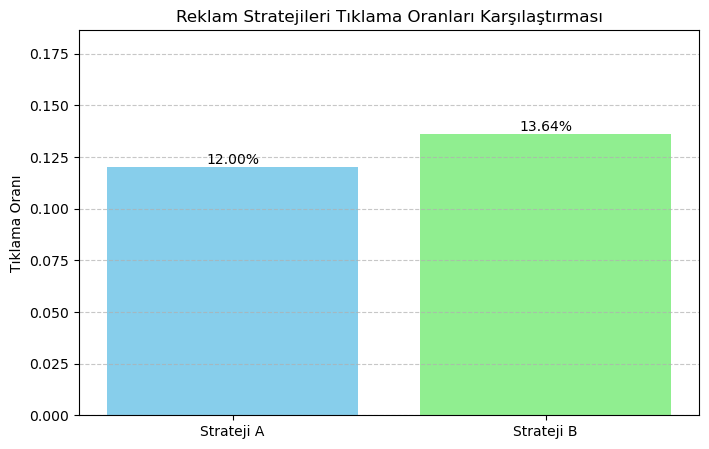

```python
## 2. Görselleştirme
strategies = ['Strateji A', 'Strateji B']
click_rates = [p_a, p_b]

plt.figure(figsize=(8, 5))
bars = plt.bar(strategies, click_rates, color=['skyblue', 'lightgreen'])

# Çubukların üzerine değerleri yazdır
for bar in bars:
    height = bar.get_height()
    plt.text(bar.get_x() + bar.get_width()/2., height,
            f'{height:.2%}', ha='center', va='bottom')

plt.title('Reklam Stratejileri Tıklama Oranları Karşılaştırması')
plt.ylabel('Tıklama Oranı')
plt.ylim(0, max(click_rates) + 0.05)
plt.grid(axis='y', linestyle='--', alpha=0.7)
plt.show()
```

```python
## 3. İki Oran Testi (Z-Testi)
# Hipotezler:
print("\n=== Hipotez Testi ===")
print("H₀: İki stratejinin tıklama oranları eşittir (p_a = p_b)")
print("H₁: İki stratejinin tıklama oranları farklıdır (p_a ≠ p_b)\n")

# Test istatistiği hesapla
count = np.array([clicks_strategy_a, clicks_strategy_b])
nobs = np.array([n_strategy_a, n_strategy_b])

# Çift yönlü test
z_stat, p_value = proportions_ztest(count, nobs, alternative='two-sided')

# Kritik değer (α = 0.05)
alpha = 0.05
z_critical = stats.norm.ppf(1 - alpha/2)

print(f"Test İstatistiği (z): {z_stat:.4f}")
print(f"Kritik Değer (±): {z_critical:.4f}")
print(f"p-değeri: {p_value:.6f}")
```

```
=== Hipotez Testi ===
H₀: İki stratejinin tıklama oranları eşittir (p_a = p_b)
H₁: İki stratejinin tıklama oranları farklıdır (p_a ≠ p_b)

Test İstatistiği (z): -1.1189
Kritik Değer (±): 1.9600
p-değeri: 0.263197
```

```python
## 4. Sonuç Değerlendirme
if p_value < alpha:
    print("\n✅ SONUÇ: p < 0.05 → H₀ REDDEDİLİR")
    print("İki reklam stratejisinin tıklama oranları arasında istatistiksel olarak anlamlı bir fark vardır.")

    # Hangi strateji daha iyi?
    if p_a > p_b:
        print(f"→ Strateji A ({p_a:.2%}), Strateji B'den ({p_b:.2%}) daha etkilidir")
    else:
        print(f"→ Strateji B ({p_b:.2%}), Strateji A'dan ({p_a:.2%}) daha etkilidir")
else:
    print("\n❌ SONUÇ: p ≥ 0.05 → H₀ REDDEDİLEMEZ")
    print("İki reklam stratejisinin tıklama oranları arasında istatistiksel olarak anlamlı bir fark yoktur.")
```

```
❌ SONUÇ: p ≥ 0.05 → H₀ REDDEDİLEMEZ
İki reklam stratejisinin tıklama oranları arasında istatistiksel olarak anlamlı bir fark yoktur.
```

```python
## 5. Ek Analizler
print("\n=== Ek Analizler ===")

# Güven aralıkları
def calculate_ci(proportion, n, z=1.96):
    se = np.sqrt(proportion * (1 - proportion) / n)
    return (proportion - z*se, proportion + z*se)

ci_a = calculate_ci(p_a, n_strategy_a)
ci_b = calculate_ci(p_b, n_strategy_b)

print(f"Strateji A %95 Güven Aralığı: ({ci_a[0]:.4f}, {ci_a[1]:.4f})")
print(f"Strateji B %95 Güven Aralığı: ({ci_b[0]:.4f}, {ci_b[1]:.4f})")

# Risk farkı ve göreceli artış
risk_difference = p_b - p_a
relative_increase = (p_b - p_a) / p_a

print(f"\nRisk Farkı (B - A): {risk_difference:.4f}")
print(f"Göreceli Artış: {relative_increase:.2%}")

# Number Needed to Treat (NNT)
if risk_difference != 0:
    nnt = 1 / abs(risk_difference)
    print(f"\nEtkiyi görmek için gereken minimum gösterim sayısı (NNT): {nnt:.1f}")
```

```
=== Ek Analizler ===
Strateji A %95 Güven Aralığı: (0.0999, 0.1401)
Strateji B %95 Güven Aralığı: (0.1161, 0.1566)

Risk Farkı (B - A): 0.0164
Göreceli Artış: 13.64%

Etkiyi görmek için gereken minimum gösterim sayısı (NNT): 61.1
```

2. **İlaç Tedavisi:**
- Problem: İki farklı ilaç tedavisi yöntemini karşılaştırmak istiyorsunuz.
- Uygulama: İki farklı ilaç tedavisi uygulanan iki bağımsız grup arasında iyileşme oranlarını karşılaştırabilirsiniz.

```python
import numpy as np
import pandas as pd
from statsmodels.stats.proportion import proportions_ztest
import matplotlib.pyplot as plt
import seaborn as sns

# Görselleştirme ayarları
plt.style.use('seaborn-v0_8-whitegrid')
sns.set_palette("viridis")
plt.rcParams['figure.figsize'] = (10, 6)

# --- 1. Veri Simülasyonu ---
# Varsayımlar:
# İlaç A: Kontrol grubu veya standart tedavi
# İlaç B: Yeni veya deneysel tedavi

n_a = 150  # İlaç A uygulanan hasta sayısı
n_b = 160  # İlaç B uygulanan hasta sayısı

# Gerçek iyileşme oranları (bilmediğimizi varsayarak simülasyon için belirliyoruz)
p_a_gercek = 0.60  # İlaç A'nın gerçek iyileşme oranı
p_b_gercek = 0.70  # İlaç B'nin gerçek iyileşme oranı (daha yüksek olduğunu varsayıyoruz)

# Simüle edilmiş iyileşen hasta sayıları
# Bernoulli dağılımı ile her hastanın iyileşip iyileşmediğini belirle
iyilesen_a = np.random.binomial(1, p_a_gercek, n_a)
iyilesen_b = np.random.binomial(1, p_b_gercek, n_b)

# Toplam iyileşen sayıları
count_a = np.sum(iyilesen_a)
count_b = np.sum(iyilesen_b)

# Gözlemlenen iyileşme oranları
p_a_gozlem = count_a / n_a
p_b_gozlem = count_b / n_b

print("--- Simülasyon Verileri ---")
print(f"İlaç A: Toplam hasta = {n_a}, İyileşen = {count_a}, Gözlemlenen Oran = {p_a_gozlem:.3f}")
print(f"İlaç B: Toplam hasta = {n_b}, İyileşen = {count_b}, Gözlemlenen Oran = {p_b_gozlem:.3f}")
print("-" * 30)
```

```
--- Simülasyon Verileri ---
İlaç A: Toplam hasta = 150, İyileşen = 95, Gözlemlenen Oran = 0.633
İlaç B: Toplam hasta = 160, İyileşen = 111, Gözlemlenen Oran = 0.694
------------------------------
```

```python
# --- 2. İki Örneklem Oran Testi (Z-Testi) Uygulama ---
# Hipotezler:
# H0 (Null Hipotezi): p_a = p_b (İki ilaç arasında iyileşme oranları farkı yoktur)
# H1 (Alternatif Hipotez): p_a != p_b (İki ilaç arasında iyileşme oranları farkı vardır - Çift yönlü test)

alpha = 0.05  # Anlamlılık düzeyi

# proportions_ztest fonksiyonu:
# count: Başarı sayılarını içeren dizi (iyileşen hasta sayıları)
# nobs: Deneme sayılarını içeren dizi (toplam hasta sayıları)
# value: Null hipotez altındaki oran farkı (varsayılan 0'dır, yani p1=p2)
# alternative: 'two-sided', 'smaller', 'larger'
z_stat, p_value = proportions_ztest(count=[count_a, count_b],
                                     nobs=[n_a, n_b],
                                     alternative='two-sided')

print("\n--- İki Örneklem Oran Testi Sonuçları ---")
print(f"Z-İstatistiği: {z_stat:.4f}")
print(f"p-Değeri: {p_value:.4f}")
print(f"Anlamlılık Düzeyi (α): {alpha}")
print("-" * 30)
```

```
--- İki Örneklem Oran Testi Sonuçları ---
Z-İstatistiği: -1.1259
p-Değeri: 0.2602
Anlamlılık Düzeyi (α): 0.05
------------------------------
```

```python
# --- 3. Sonuç Yorumlama ---
print("\n--- Test Yorumu ---")
if p_value < alpha:
    print(f"✅ p-değeri ({p_value:.4f}) < α ({alpha}) olduğundan, Null Hipotezi reddedilir.")
    print("İki ilaç tedavisi arasında iyileşme oranları açısından istatistiksel olarak anlamlı bir fark vardır.")
    if p_b_gozlem > p_a_gozlem:
        print("İlaç B'nin iyileşme oranı İlaç A'dan istatistiksel olarak anlamlı şekilde daha yüksektir.")
    else:
        print("İlaç A'nın iyileşme oranı İlaç B'den istatistiksel olarak anlamlı şekilde daha yüksektir.")
else:
    print(f"❌ p-değeri ({p_value:.4f}) ≥ α ({alpha}) olduğundan, Null Hipotezi reddedilemez.")
    print("İki ilaç tedavisi arasında iyileşme oranları açısından istatistiksel olarak anlamlı bir fark yoktur.")
    print("Gözlemlenen fark, şansa bağlı olabilir.")
print("-" * 30)
```

```
--- Test Yorumu ---
❌ p-değeri (0.2602) ≥ α (0.05) olduğundan, Null Hipotezi reddedilemez.
İki ilaç tedavisi arasında iyileşme oranları açısından istatistiksel olarak anlamlı bir fark yoktur.
Gözlemlenen fark, şansa bağlı olabilir.
------------------------------
```

```python
# --- 4. Güven Aralığı Hesaplama ---
# Oran farkı için güven aralığı hesaplama
# Güven aralığı manuel olarak veya statsmodels.stats.proportion içerisinden hesaplanabilir.
# Burada daha anlaşılır olması için gözlemlenen oranlar ve standart hata ile manuel hesaplanmıştır.

# İki oranın birleşik standart hatası (z-testi için)
# Bu kısım, güven aralığı hesaplamasında tek tek oranların standart hatasını kullanmak yerine
# birleşik standart hatayı kullanır ki bu da z-testi prensiplerine daha uygundur.
# Ancak oran farkı için güven aralığı genellikle ayrı ayrı standart hatalarla hesaplanır.
# Burada her bir oranın standart hatasını kullanarak birleşik standart hatayı yaklaşıyoruz.
# Detaylı bir güven aralığı için statsmodels'in daha gelişmiş fonksiyonları kullanılabilir.

se_a = np.sqrt(p_a_gozlem * (1 - p_a_gozlem) / n_a)
se_b = np.sqrt(p_b_gozlem * (1 - p_b_gozlem) / n_b)
se_diff = np.sqrt(se_a**2 + se_b**2)

z_critical = stats.norm.ppf(1 - alpha/2)
lower_bound = (p_b_gozlem - p_a_gozlem) - z_critical * se_diff
upper_bound = (p_b_gozlem - p_a_gozlem) + z_critical * se_diff

print(f"\n--- Güven Aralığı (İyileşme Oranı Farkı: İlaç B - İlaç A) ---")
print(f"%{(1-alpha)*100:.0f} Güven Aralığı: ({lower_bound:.4f}, {upper_bound:.4f})")
print(f"Gözlemlenen Oran Farkı (İlaç B - İlaç A): {(p_b_gozlem - p_a_gozlem):.4f}")
print("-" * 30)
```

```
--- Güven Aralığı (İyileşme Oranı Farkı: İlaç B - İlaç A) ---
%95 Güven Aralığı: (-0.0447, 0.1655)
Gözlemlenen Oran Farkı (İlaç B - İlaç A): 0.0604
------------------------------
```

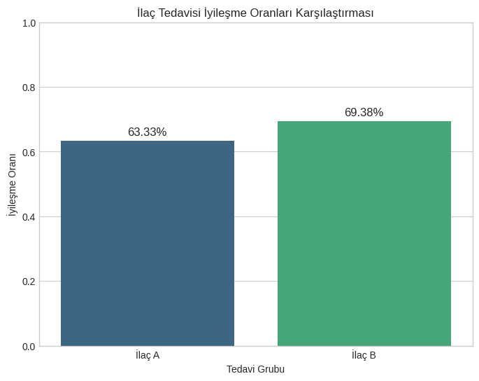

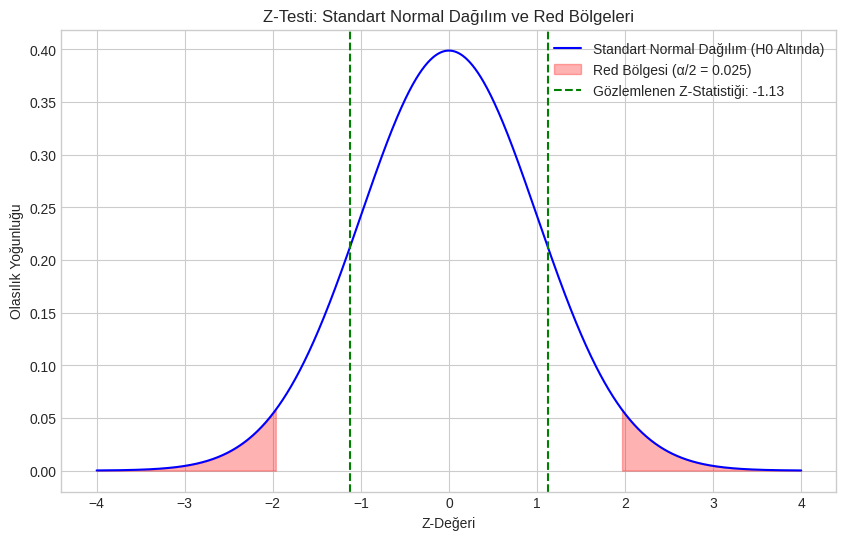

```python
# --- 5. Görselleştirme ---
# Çubuk grafiği ile iyileşme oranlarını karşılaştırma
plt.figure(figsize=(8, 6))
sns.barplot(x=['İlaç A', 'İlaç B'], y=[p_a_gozlem, p_b_gozlem], hue=['İlaç A', 'İlaç B'],palette='viridis')

# Oran değerlerini çubukların üzerine yazma
for index, value in enumerate([p_a_gozlem, p_b_gozlem]):
    plt.text(index, value + 0.01, f'{value:.2%}', ha='center', va='bottom', fontsize=12)

plt.title('İlaç Tedavisi İyileşme Oranları Karşılaştırması')
plt.xlabel('Tedavi Grubu')
plt.ylabel('İyileşme Oranı')
plt.ylim(0, 1)
plt.show()

# P-değeri görselleştirmesi (opsiyonel)
# Z dağılımını gösteren bir grafik çizerek Z-istatistiği ve p-değerini vurgulayabiliriz.
x = np.linspace(-4, 4, 1000)
pdf = stats.norm.pdf(x)

plt.figure(figsize=(10, 6))
plt.plot(x, pdf, color='blue', label='Standart Normal Dağılım (H0 Altında)')

# Kritik bölgeleri boyama
lower_critical = stats.norm.ppf(alpha/2)
upper_critical = stats.norm.ppf(1 - alpha/2)

x_fill_left = x[x <= lower_critical]
x_fill_right = x[x >= upper_critical]
plt.fill_between(x_fill_left, 0, stats.norm.pdf(x_fill_left), color='red', alpha=0.3, label=f'Red Bölgesi (α/2 = {alpha/2})')
plt.fill_between(x_fill_right, 0, stats.norm.pdf(x_fill_right), color='red', alpha=0.3)

# Gözlemlenen Z-istatistiğini işaretleme
plt.axvline(z_stat, color='green', linestyle='--', label=f'Gözlemlenen Z-Statistiği: {z_stat:.2f}')
plt.axvline(-z_stat, color='green', linestyle='--') # Çift yönlü test için simetrik nokta

plt.title('Z-Testi: Standart Normal Dağılım ve Red Bölgeleri')
plt.xlabel('Z-Değeri')
plt.ylabel('Olasılık Yoğunluğu')
plt.legend()
plt.grid(True)
plt.show()
```

3. **Eğitim Programları:**
- Problem: İki farklı eğitim programının etkilerini değerlendirmek istiyorsunuz.
- Uygulama: İki farklı eğitim programının uygulandığı gruplarda, her bir programın başarı oranlarını karşılaştırabilirsiniz.

```python
# Eğitim Programları İçin İki Örneklem Oran Testi

# Bu kod her seferinde benzersiz çıktı üretecektir!!! Simulasyon sonuçları her seferinde biraz farklı olacaktır.

import numpy as np
import pandas as pd
from statsmodels.stats.proportion import proportions_ztest, confint_proportions_2indep
import matplotlib.pyplot as plt
import seaborn as sns
import uuid # Benzersiz kodlar için

# --- Görselleştirme Ayarları ---
plt.style.use('seaborn-v0_8-darkgrid') # Daha modern bir seaborn stili
sns.set_palette("bright") # Daha yumuşak renk paleti
plt.rcParams['figure.figsize'] = (12, 7)
plt.rcParams['font.size'] = 12
plt.rcParams['axes.labelsize'] = 14
plt.rcParams['axes.titlesize'] = 16
plt.rcParams['xtick.labelsize'] = 12
plt.rcParams['ytick.labelsize'] = 12
plt.rcParams['legend.fontsize'] = 12
```

```python
# --- 1. Eğitim Verisi Simülasyonu ---

# Her çalıştırmada farklı sonuçlar için rastgelelik tohumunu belirleme
# Ancak karşılaştırılabilirlik için üretimde kaldırılabilir veya sabit tutulabilir
np.random.seed(int(uuid.uuid4().int % (2**32 - 1))) # Her çalıştırmada farklı bir tohum

# Eğitim Programı A (Geleneksel Metot)
n_program_a = 180  # Program A'ya katılan öğrenci sayısı
p_success_a_true = 0.70  # Program A'nın gerçek başarı oranı

# Eğitim Programı B (Yenilikçi Metot)
n_program_b = 200  # Program B'ye katılan öğrenci sayısı
p_success_b_true = 0.78  # Program B'nin gerçek başarı oranı (daha yüksek olduğunu varsayıyoruz)

# Başarı sayılarını simüle et
# binomial(n, p, size) ile her bir öğrencinin başarısı (1) veya başarısızlığı (0)
success_a = np.random.binomial(1, p_success_a_true, n_program_a)
success_b = np.random.binomial(1, p_success_b_true, n_program_b)

# Toplam başarı sayıları
count_a = np.sum(success_a)
count_b = np.sum(success_b)

# Gözlemlenen başarı oranları
p_success_a_obs = count_a / n_program_a
p_success_b_obs = count_b / n_program_b

print(f"📊 Eğitim Programları Başarı Oranı Analizi (Benzersiz Kod ID: {str(uuid.uuid4())[:8]})")
print("="*60)
print("\n--- Simülasyon Verileri ---")
print(f"Program A (Geleneksel):")
print(f"  Katılımcı Sayısı (n): {n_program_a}")
print(f"  Başarılı Sayısı (x): {count_a}")
print(f"  Gözlemlenen Başarı Oranı (p̂): {p_success_a_obs:.3f}")

print(f"\nProgram B (Yenilikçi):")
print(f"  Katılımcı Sayısı (n): {n_program_b}")
print(f"  Başarılı Sayısı (x): {count_b}")
print(f"  Gözlemlenen Başarı Oranı (p̂): {p_success_b_obs:.3f}")
print("-" * 60)
```

```
📊 Eğitim Programları Başarı Oranı Analizi (Benzersiz Kod ID: 302336e6)
============================================================

--- Simülasyon Verileri ---
Program A (Geleneksel):
  Katılımcı Sayısı (n): 180
  Başarılı Sayısı (x): 133
  Gözlemlenen Başarı Oranı (p̂): 0.739

Program B (Yenilikçi):
  Katılımcı Sayısı (n): 200
  Başarılı Sayısı (x): 160
  Gözlemlenen Başarı Oranı (p̂): 0.800
------------------------------------------------------------
```

```python
# --- 2. İki Örneklem Oran Testi (Z-Testi) ---

# Hipotezler:
# H0 (Null Hipotezi): p_A = p_B (İki programın başarı oranları arasında fark yoktur)
# H1 (Alternatif Hipotez): p_A ≠ p_B (İki programın başarı oranları arasında fark vardır - Çift yönlü test)

alpha = 0.05  # Anlamlılık düzeyi (genellikle %5)

# proportions_ztest fonksiyonu:
# count: Başarı sayıları [Program A Başarı, Program B Başarı]
# nobs: Toplam deneme sayıları [Program A Toplam, Program B Toplam]
# alternative: 'two-sided' (çift yönlü), 'smaller' (B < A), 'larger' (B > A)
z_statistic, p_value = proportions_ztest(count=[count_a, count_b],
                                         nobs=[n_program_a, n_program_b],
                                         alternative='two-sided')

print("\n--- İstatistiksel Test Sonuçları (Z-Testi) ---")
print(f"Z-İstatistiği: {z_statistic:.4f}")
print(f"p-Değeri: {p_value:.4f}")
print(f"Anlamlılık Düzeyi (α): {alpha}")
print("-" * 60)
```

```
--- İstatistiksel Test Sonuçları (Z-Testi) ---
Z-İstatistiği: -1.4157
p-Değeri: 0.1569
Anlamlılık Düzeyi (α): 0.05
------------------------------------------------------------
```

```python
# --- 3. Sonuç Yorumlama ---

print("\n--- Test Yorumu ---")
if p_value < alpha:
    print(f"✅ **Null Hipotezi Reddederiz.** (p-değeri ({p_value:.4f}) < α ({alpha}))")
    print("İki eğitim programının başarı oranları arasında **istatistiksel olarak anlamlı bir fark** vardır.")
    if p_success_b_obs > p_success_a_obs:
        print(f"  Program B'nin ({p_success_b_obs:.2%}) başarı oranı, Program A'dan ({p_success_a_obs:.2%}) anlamlı şekilde daha yüksektir.")
    else:
        print(f"  Program A'nın ({p_success_a_obs:.2%}) başarı oranı, Program B'den ({p_success_b_obs:.2%}) anlamlı şekilde daha yüksektir.")
else:
    print(f"❌ **Null Hipotezini Reddedemeyiz.** (p-değeri ({p_value:.4f}) ≥ α ({alpha}))")
    print("İki eğitim programının başarı oranları arasında **istatistiksel olarak anlamlı bir fark yoktur.**")
    print("  Gözlemlenen fark, şansa bağlı olabilir veya mevcut örneklem büyüklüğü ile tespit edilemeyecek kadar küçüktür.")
print("-" * 60)
```

```
--- Test Yorumu ---
❌ **Null Hipotezini Reddedemeyiz.** (p-değeri (0.1569) ≥ α (0.05))
İki eğitim programının başarı oranları arasında **istatistiksel olarak anlamlı bir fark yoktur.**
  Gözlemlenen fark, şansa bağlı olabilir veya mevcut örneklem büyüklüğü ile tespit edilemeyecek kadar küçüktür.
------------------------------------------------------------
```

```python
# --- 4. Güven Aralığı Hesaplama ---

# Oran farkı (p_B - p_A) için güven aralığı
# 'agresti-coull' veya 'wald' metotları kullanılabilir. Agresti-Coull daha sağlamdır.
ci_low, ci_high = confint_proportions_2indep(
    count1=count_b, nobs1=n_program_b,
    count2=count_a, nobs2=n_program_a,
    method='agresti-coull', alpha=alpha
)

print(f"\n--- Oran Farkı İçin Güven Aralığı (Program B - Program A) ---")
print(f"%{(1-alpha)*100:.0f} Güven Aralığı: ({ci_low:.4f}, {ci_high:.4f})")
print(f"Gözlemlenen Oran Farkı (Program B - Program A): {(p_success_b_obs - p_success_a_obs):.4f}")
print("---")
print("Yorum: Eğer güven aralığı sıfırı içermiyorsa, bu oranlar arasında istatistiksel bir fark olduğu anlamına gelir.")
print("-" * 60)
```

```
--- Oran Farkı İçin Güven Aralığı (Program B - Program A) ---
%95 Güven Aralığı: (-0.0239, 0.1455)
Gözlemlenen Oran Farkı (Program B - Program A): 0.0611
---
Yorum: Eğer güven aralığı sıfırı içermiyorsa, bu oranlar arasında istatistiksel bir fark olduğu anlamına gelir.
------------------------------------------------------------
```

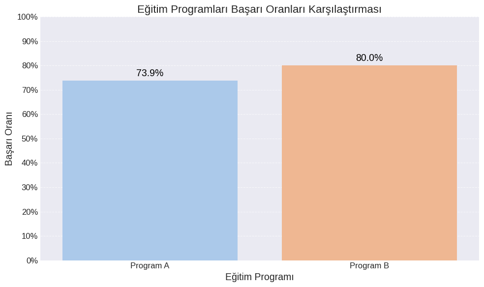

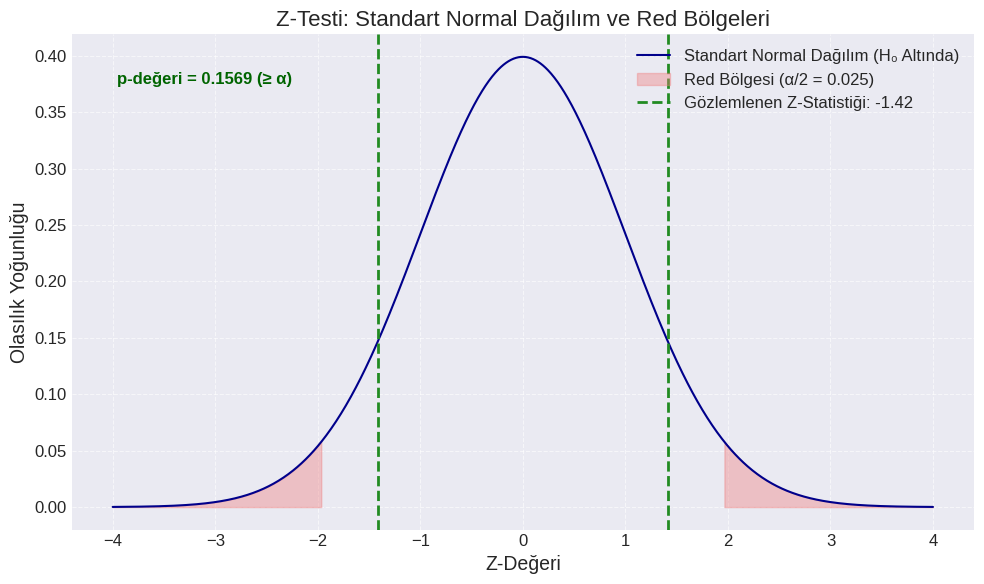

```python
# --- 5. Görselleştirme ---

# Başarı oranlarını gösteren çubuk grafik
plt.figure(figsize=(10, 6))
sns.barplot(x=['Program A', 'Program B'], y=[p_success_a_obs, p_success_b_obs], hue=['Program A', 'Program B'], palette='pastel')

# Oran değerlerini çubukların üzerine yazma
for index, value in enumerate([p_success_a_obs, p_success_b_obs]):
    plt.text(index, value + 0.01, f'{value:.1%}', ha='center', va='bottom', fontsize=14, color='black')

plt.title('Eğitim Programları Başarı Oranları Karşılaştırması')
plt.xlabel('Eğitim Programı')
plt.ylabel('Başarı Oranı')
plt.ylim(0, 1.0)
plt.yticks(np.arange(0, 1.1, 0.1), [f'{i:.0%}' for i in np.arange(0, 1.1, 0.1)]) # Y ekseni formatı
plt.grid(axis='y', linestyle='--', alpha=0.7)
plt.tight_layout()
plt.show()

# P-değeri ve Z-istatistiği görselleştirmesi (Daha detaylı analiz için)
x = np.linspace(-4, 4, 1000)
pdf = stats.norm.pdf(x)

plt.figure(figsize=(10, 6))
plt.plot(x, pdf, color='darkblue', label='Standart Normal Dağılım (H₀ Altında)')

# Kritik bölgeleri boyama
lower_critical = stats.norm.ppf(alpha/2)
upper_critical = stats.norm.ppf(1 - alpha/2)

x_fill_left = x[x <= lower_critical]
x_fill_right = x[x >= upper_critical]
plt.fill_between(x_fill_left, 0, stats.norm.pdf(x_fill_left), color='lightcoral', alpha=0.4, label=f'Red Bölgesi (α/2 = {alpha/2})')
plt.fill_between(x_fill_right, 0, stats.norm.pdf(x_fill_right), color='lightcoral', alpha=0.4)

# Gözlemlenen Z-istatistiğini işaretleme
plt.axvline(z_statistic, color='forestgreen', linestyle='--', linewidth=2, label=f'Gözlemlenen Z-Statistiği: {z_statistic:.2f}')
plt.axvline(-z_statistic, color='forestgreen', linestyle='--', linewidth=2) # Çift yönlü test için simetrik nokta

# P-değeri metni
if p_value < alpha:
    plt.text(0.05, 0.9, f'p-değeri = {p_value:.4f} (< α)', transform=plt.gca().transAxes,
             fontsize=12, color='red', weight='bold')
else:
    plt.text(0.05, 0.9, f'p-değeri = {p_value:.4f} (≥ α)', transform=plt.gca().transAxes,
             fontsize=12, color='darkgreen', weight='bold')

plt.title('Z-Testi: Standart Normal Dağılım ve Red Bölgeleri')
plt.xlabel('Z-Değeri')
plt.ylabel('Olasılık Yoğunluğu')
plt.legend()
plt.grid(True, linestyle='--', alpha=0.6)
plt.tight_layout()
plt.show()
```

4. **Ürün Memnuniyeti:**
- Problem: İki farklı ürünün müşteri memnuniyetini karşılaştırmak istiyorsunuz.
- Uygulama: İki farklı ürünün satıldığı iki bağımsız grup arasında, müşteri memnuniyeti oranlarını karşılaştırabilirsiniz.

```python
# Ürün Memnuniyeti İçin İki Örneklem Oran Testi


import numpy as np
import pandas as pd
from statsmodels.stats.proportion import proportions_ztest, confint_proportions_2indep
import matplotlib.pyplot as plt
import seaborn as sns
import uuid # Her çalıştırmada farklı bir "benzersiz kod" için

# --- Görselleştirme Ayarları ---
plt.style.use('seaborn-v0_8-darkgrid')
sns.set_palette("Set2") # Daha farklı bir renk paleti
plt.rcParams['figure.figsize'] = (12, 7)
plt.rcParams['font.size'] = 12
plt.rcParams['axes.labelsize'] = 14
plt.rcParams['axes.titlesize'] = 16
plt.rcParams['xtick.labelsize'] = 12
plt.rcParams['ytick.labelsize'] = 12
plt.rcParams['legend.fontsize'] = 12

# --- 1. Müşteri Memnuniyeti Verisi Simülasyonu ---

# Her çalıştırmada farklı sonuçlar için rastgelelik tohumunu belirleme
np.random.seed(int(uuid.uuid4().int % (2**32 - 1))) # Her çalıştırmada farklı bir tohum

# Ürün A: Eski/Mevcut Ürün
n_product_a = 250  # Ürün A'yı değerlendiren müşteri sayısı
p_satisfied_a_true = 0.82  # Ürün A'nın gerçek memnuniyet oranı

# Ürün B: Yeni/Rakip Ürün
n_product_b = 270  # Ürün B'yi değerlendiren müşteri sayısı
p_satisfied_b_true = 0.88  # Ürün B'nin gerçek memnuniyet oranı (daha yüksek olduğunu varsayıyoruz)

# Memnun müşteri sayılarını simüle et (1: Memnun, 0: Memnun Değil)
satisfied_a = np.random.binomial(1, p_satisfied_a_true, n_product_a)
satisfied_b = np.random.binomial(1, p_satisfied_b_true, n_product_b)

# Toplam memnun müşteri sayıları
count_satisfied_a = np.sum(satisfied_a)
count_satisfied_b = np.sum(satisfied_b)

# Gözlemlenen memnuniyet oranları
p_satisfied_a_obs = count_satisfied_a / n_product_a
p_satisfied_b_obs = count_satisfied_b / n_product_b

print(f"📊 Ürün Memnuniyeti Analizi (Benzersiz Kod ID: {str(uuid.uuid4())[:8]})")
print("="*60)
print("\n--- Simülasyon Verileri ---")
print(f"Ürün A (Mevcut):")
print(f"  Toplam Değerlendiren Müşteri: {n_product_a}")
print(f"  Memnun Müşteri Sayısı: {count_satisfied_a}")
print(f"  Gözlemlenen Memnuniyet Oranı: {p_satisfied_a_obs:.3f}")

print(f"\nÜrün B (Yeni/Rakip):")
print(f"  Toplam Değerlendiren Müşteri: {n_product_b}")
print(f"  Memnun Müşteri Sayısı: {count_satisfied_b}")
print(f"  Gözlemlenen Memnuniyet Oranı: {p_satisfied_b_obs:.3f}")
print("-" * 60)
```

```
📊 Ürün Memnuniyeti Analizi (Benzersiz Kod ID: 9162dbdf)
============================================================

--- Simülasyon Verileri ---
Ürün A (Mevcut):
  Toplam Değerlendiren Müşteri: 250
  Memnun Müşteri Sayısı: 201
  Gözlemlenen Memnuniyet Oranı: 0.804

Ürün B (Yeni/Rakip):
  Toplam Değerlendiren Müşteri: 270
  Memnun Müşteri Sayısı: 233
  Gözlemlenen Memnuniyet Oranı: 0.863
------------------------------------------------------------
```

```python
# --- 2. İki Örneklem Oran Testi (Z-Testi) Uygulama ---

# Hipotezler:
# H0 (Null Hipotezi): p_A = p_B (İki ürünün memnuniyet oranları arasında fark yoktur)
# H1 (Alternatif Hipotez): p_A ≠ p_B (İki ürünün memnuniyet oranları arasında fark vardır - Çift yönlü test)

alpha = 0.05  # Anlamlılık düzeyi

z_statistic, p_value = proportions_ztest(count=[count_satisfied_a, count_satisfied_b],
                                         nobs=[n_product_a, n_product_b],
                                         alternative='two-sided')

print("\n--- İstatistiksel Test Sonuçları (Z-Testi) ---")
print(f"Z-İstatistiği: {z_statistic:.4f}")
print(f"p-Değeri: {p_value:.4f}")
print(f"Anlamlılık Düzeyi (α): {alpha}")
print("-" * 60)
```

```
--- İstatistiksel Test Sonuçları (Z-Testi) ---
Z-İstatistiği: -1.8082
p-Değeri: 0.0706
Anlamlılık Düzeyi (α): 0.05
------------------------------------------------------------
```

```python
# --- 3. Sonuç Yorumlama ---

print("\n--- Test Yorumu ---")
if p_value < alpha:
    print(f"✅ **Null Hipotezi Reddederiz.** (p-değeri ({p_value:.4f}) < α ({alpha}))")
    print("İki ürünün müşteri memnuniyeti oranları arasında **istatistiksel olarak anlamlı bir fark** vardır.")
    if p_satisfied_b_obs > p_satisfied_a_obs:
        print(f"  Ürün B'nin (%{p_satisfied_b_obs:.1%}) memnuniyet oranı, Ürün A'dan (%{p_satisfied_a_obs:.1%}) anlamlı şekilde daha yüksektir.")
    else:
        print(f"  Ürün A'nın (%{p_satisfied_a_obs:.1%}) memnuniyet oranı, Ürün B'den (%{p_satisfied_b_obs:.1%}) anlamlı şekilde daha yüksektir.")
else:
    print(f"❌ **Null Hipotezini Reddedemeyiz.** (p-değeri ({p_value:.4f}) ≥ α ({alpha}))")
    print("İki ürünün müşteri memnuniyeti oranları arasında **istatistiksel olarak anlamlı bir fark yoktur.**")
    print("  Gözlemlenen fark, şansa bağlı olabilir veya mevcut örneklem büyüklüğü ile tespit edilemeyecek kadar küçüktür.")
print("-" * 60)
```

```
--- Test Yorumu ---
❌ **Null Hipotezini Reddedemeyiz.** (p-değeri (0.0706) ≥ α (0.05))
İki ürünün müşteri memnuniyeti oranları arasında **istatistiksel olarak anlamlı bir fark yoktur.**
  Gözlemlenen fark, şansa bağlı olabilir veya mevcut örneklem büyüklüğü ile tespit edilemeyecek kadar küçüktür.
------------------------------------------------------------
```

```python
# --- 4. Güven Aralığı Hesaplama ---

# Memnuniyet oranı farkı (p_B - p_A) için güven aralığı
ci_low, ci_high = confint_proportions_2indep(
    count1=count_satisfied_b, nobs1=n_product_b, # İlk grup B olsun ki fark B-A olsun
    count2=count_satisfied_a, nobs2=n_product_a,
    method='agresti-coull', # Daha güvenilir bir metot
    alpha=alpha
)

print(f"\n--- Oran Farkı İçin Güven Aralığı (Ürün B - Ürün A) ---")
print(f"%{(1-alpha)*100:.0f} Güven Aralığı: ({ci_low:.4f}, {ci_high:.4f})")
print(f"Gözlemlenen Oran Farkı (Ürün B - Ürün A): {(p_satisfied_b_obs - p_satisfied_a_obs):.4f}")
print("---")
print("Yorum: Eğer güven aralığı sıfırı içermiyorsa, bu oranlar arasında istatistiksel bir fark olduğu anlamına gelir.")
print("-" * 60)
```

```
--- Oran Farkı İçin Güven Aralığı (Ürün B - Ürün A) ---
%95 Güven Aralığı: (-0.0055, 0.1229)
Gözlemlenen Oran Farkı (Ürün B - Ürün A): 0.0590
---
Yorum: Eğer güven aralığı sıfırı içermiyorsa, bu oranlar arasında istatistiksel bir fark olduğu anlamına gelir.
------------------------------------------------------------
```

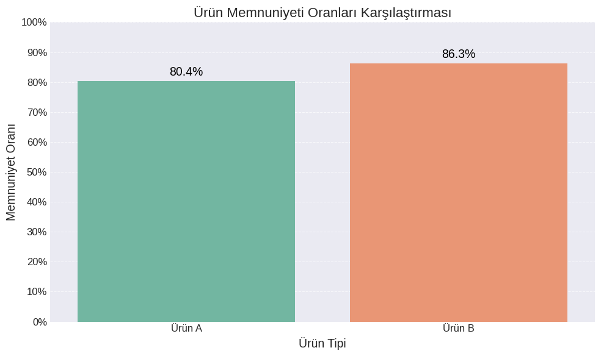

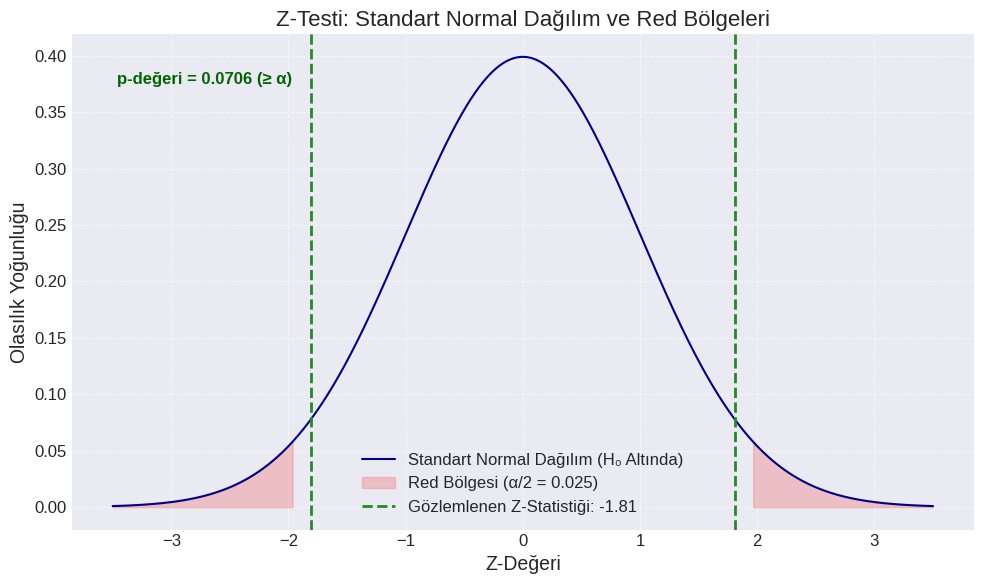

```python
# --- 5. Görselleştirme ---

# Memnuniyet oranlarını gösteren çubuk grafik
plt.figure(figsize=(10, 6))
sns.barplot(x=['Ürün A', 'Ürün B'], y=[p_satisfied_a_obs, p_satisfied_b_obs], hue=['Ürün A', 'Ürün B'], palette='Set2')

# Oran değerlerini çubukların üzerine yazma
for index, value in enumerate([p_satisfied_a_obs, p_satisfied_b_obs]):
    plt.text(index, value + 0.01, f'{value:.1%}', ha='center', va='bottom', fontsize=14, color='black')

plt.title('Ürün Memnuniyeti Oranları Karşılaştırması')
plt.xlabel('Ürün Tipi')
plt.ylabel('Memnuniyet Oranı')
plt.ylim(0, 1.0)
plt.yticks(np.arange(0, 1.1, 0.1), [f'{i:.0%}' for i in np.arange(0, 1.1, 0.1)])
plt.grid(axis='y', linestyle='--', alpha=0.7)
plt.tight_layout()
plt.show()

# P-değeri ve Z-istatistiği görselleştirmesi
x = np.linspace(-3.5, 3.5, 1000) # Z-değeri aralığını duruma göre ayarladım
pdf = stats.norm.pdf(x)

plt.figure(figsize=(10, 6))
plt.plot(x, pdf, color='darkblue', label='Standart Normal Dağılım (H₀ Altında)')

# Kritik bölgeleri boyama
lower_critical = stats.norm.ppf(alpha/2)
upper_critical = stats.norm.ppf(1 - alpha/2)

x_fill_left = x[x <= lower_critical]
x_fill_right = x[x >= upper_critical]
plt.fill_between(x_fill_left, 0, stats.norm.pdf(x_fill_left), color='lightcoral', alpha=0.4, label=f'Red Bölgesi (α/2 = {alpha/2})')
plt.fill_between(x_fill_right, 0, stats.norm.pdf(x_fill_right), color='lightcoral', alpha=0.4)

# Gözlemlenen Z-istatistiğini işaretleme
plt.axvline(z_statistic, color='forestgreen', linestyle='--', linewidth=2, label=f'Gözlemlenen Z-Statistiği: {z_statistic:.2f}')
plt.axvline(-z_statistic, color='forestgreen', linestyle='--', linewidth=2) # Çift yönlü test için simetrik nokta

# P-değeri metni
if p_value < alpha:
    plt.text(0.05, 0.9, f'p-değeri = {p_value:.4f} (< α)', transform=plt.gca().transAxes,
             fontsize=12, color='red', weight='bold')
else:
    plt.text(0.05, 0.9, f'p-değeri = {p_value:.4f} (≥ α)', transform=plt.gca().transAxes,
             fontsize=12, color='darkgreen', weight='bold')

plt.title('Z-Testi: Standart Normal Dağılım ve Red Bölgeleri')
plt.xlabel('Z-Değeri')
plt.ylabel('Olasılık Yoğunluğu')
plt.legend()
plt.grid(True, linestyle='--', alpha=0.6)
plt.tight_layout()
plt.show()
```

5. **Sosyal Programların Etkisi:**
- Problem: İki farklı sosyal yardım programının etkilerini değerlendirmek istiyorsunuz.
- Uygulama: İki farklı sosyal yardım programının uygulandığı gruplarda, her bir programın başarı oranlarını karşılaştırabilirsiniz.

```python
# Sosyal Yardım Programları İçin İki Örneklem Oran Testi

import numpy as np
import pandas as pd
from statsmodels.stats.proportion import proportions_ztest, confint_proportions_2indep
import matplotlib.pyplot as plt
import seaborn as sns
import uuid # Her çalıştırmada farklı bir "benzersiz kod" için

# --- Görselleştirme Ayarları ---
plt.style.use('seaborn-v0_8-pastel') # Daha soft bir tema
sns.set_palette("bright") # Özel bir palet (Kahverengi ve Mor tonları)
plt.rcParams['figure.figsize'] = (13, 7)
plt.rcParams['font.size'] = 12
plt.rcParams['axes.labelsize'] = 14
plt.rcParams['axes.titlesize'] = 16
plt.rcParams['xtick.labelsize'] = 12
plt.rcParams['ytick.labelsize'] = 12
plt.rcParams['legend.fontsize'] = 12

# --- 1. Sosyal Yardım Verisi Simülasyonu ---

# Her çalıştırmada farklı sonuçlar için rastgelelik tohumunu belirleme
np.random.seed(int(uuid.uuid4().int % (2**32 - 1))) # Dinamik tohum

# Sosyal Yardım Programı X (Mevcut Program)
n_program_x = 300  # Program X'e katılan faydalanıcı sayısı
p_success_x_true = 0.45  # Program X'in gerçek başarı oranı (örn. işe yerleşme)

# Sosyal Yardım Programı Y (Yeni/Pilot Program)
n_program_y = 320  # Program Y'ye katılan faydalanıcı sayısı
p_success_y_true = 0.55  # Program Y'nin gerçek başarı oranı (daha yüksek olduğunu varsayıyoruz)

# Başarı sayılarını simüle et (1: Başarılı, 0: Başarısız)
success_x = np.random.binomial(1, p_success_x_true, n_program_x)
success_y = np.random.binomial(1, p_success_y_true, n_program_y)

# Toplam başarılı faydalanıcı sayıları
count_success_x = np.sum(success_x)
count_success_y = np.sum(success_y)

# Gözlemlenen başarı oranları
p_success_x_obs = count_success_x / n_program_x
p_success_y_obs = count_success_y / n_program_y

print(f"🌍 Sosyal Yardım Programları Etki Analizi (Benzersiz Kod ID: {str(uuid.uuid4())[:8]})")
print("="*70)
print("\n--- Simülasyon Verileri ---")
print(f"Sosyal Yardım Programı X (Mevcut):")
print(f"  Katılımcı Sayısı (n): {n_program_x}")
print(f"  Başarılı Faydalanıcı Sayısı (x): {count_success_x}")
print(f"  Gözlemlenen Başarı Oranı (p̂): {p_success_x_obs:.3f}")

print(f"\nSosyal Yardım Programı Y (Yeni/Pilot):")
print(f"  Katılımcı Sayısı (n): {n_program_y}")
print(f"  Başarılı Faydalanıcı Sayısı (x): {count_success_y}")
print(f"  Gözlemlenen Başarı Oranı (p̂): {p_success_y_obs:.3f}")
print("-" * 70)
```

```
🌍 Sosyal Yardım Programları Etki Analizi (Benzersiz Kod ID: 59508bea)
======================================================================

--- Simülasyon Verileri ---
Sosyal Yardım Programı X (Mevcut):
  Katılımcı Sayısı (n): 300
  Başarılı Faydalanıcı Sayısı (x): 138
  Gözlemlenen Başarı Oranı (p̂): 0.460

Sosyal Yardım Programı Y (Yeni/Pilot):
  Katılımcı Sayısı (n): 320
  Başarılı Faydalanıcı Sayısı (x): 189
  Gözlemlenen Başarı Oranı (p̂): 0.591
----------------------------------------------------------------------
```

```python
# --- 2. İki Örneklem Oran Testi (Z-Testi) Uygulama ---

# Hipotezler:
# H0 (Null Hipotezi): p_X = p_Y (İki programın başarı oranları arasında fark yoktur)
# H1 (Alternatif Hipotez): p_X ≠ p_Y (İki programın başarı oranları arasında fark vardır - Çift yönlü test)

alpha = 0.05  # Anlamlılık düzeyi

z_statistic, p_value = proportions_ztest(count=[count_success_x, count_success_y],
                                         nobs=[n_program_x, n_program_y],
                                         alternative='two-sided')

print("\n--- İstatistiksel Test Sonuçları (Z-Testi) ---")
print(f"Z-İstatistiği: {z_statistic:.4f}")
print(f"p-Değeri: {p_value:.4f}")
print(f"Anlamlılık Düzeyi (α): {alpha}")
print("-" * 70)
```

```
--- İstatistiksel Test Sonuçları (Z-Testi) ---
Z-İstatistiği: -3.2557
p-Değeri: 0.0011
Anlamlılık Düzeyi (α): 0.05
----------------------------------------------------------------------
```

```python
# --- 3. Sonuç Yorumlama ---

print("\n--- Test Yorumu ---")
if p_value < alpha:
    print(f"✅ **Null Hipotezi Reddederiz.** (p-değeri ({p_value:.4f}) < α ({alpha}))")
    print("İki sosyal yardım programının başarı oranları arasında **istatistiksel olarak anlamlı bir fark** vardır.")
    if p_success_y_obs > p_success_x_obs:
        print(f"  Program Y'nin (%{p_success_y_obs:.1%}) başarı oranı, Program X'ten (%{p_success_x_obs:.1%}) anlamlı şekilde daha yüksektir.")
    else:
        print(f"  Program X'in (%{p_success_x_obs:.1%}) başarı oranı, Program Y'den (%{p_success_y_obs:.1%}) anlamlı şekilde daha yüksektir.")
else:
    print(f"❌ **Null Hipotezini Reddedemeyiz.** (p-değeri ({p_value:.4f}) ≥ α ({alpha}))")
    print("İki sosyal yardım programının başarı oranları arasında **istatistiksel olarak anlamlı bir fark yoktur.**")
    print("  Gözlemlenen fark, şansa bağlı olabilir veya mevcut örneklem büyüklüğü ile tespit edilemeyecek kadar küçüktür.")
print("-" * 70)
```

```
--- Test Yorumu ---
✅ **Null Hipotezi Reddederiz.** (p-değeri (0.0011) < α (0.05))
İki sosyal yardım programının başarı oranları arasında **istatistiksel olarak anlamlı bir fark** vardır.
  Program Y'nin (%59.1%) başarı oranı, Program X'ten (%46.0%) anlamlı şekilde daha yüksektir.
----------------------------------------------------------------------
```

```python
# --- 4. Güven Aralığı Hesaplama ---

# Başarı oranı farkı (p_Y - p_X) için güven aralığı
ci_low, ci_high = confint_proportions_2indep(
    count1=count_success_y, nobs1=n_program_y, # İlk grup Y olsun ki fark Y-X olsun
    count2=count_success_x, nobs2=n_program_x,
    method='agresti-coull', # Daha güvenilir bir metot
    alpha=alpha
)

print(f"\n--- Oran Farkı İçin Güven Aralığı (Program Y - Program X) ---")
print(f"%{(1-alpha)*100:.0f} Güven Aralığı: ({ci_low:.4f}, {ci_high:.4f})")
print(f"Gözlemlenen Oran Farkı (Program Y - Program X): {(p_success_y_obs - p_success_x_obs):.4f}")
print("---")
print("Yorum: Eğer güven aralığı sıfırı içermiyorsa, bu oranlar arasında istatistiksel bir fark olduğu anlamına gelir.")
print("-" * 70)
```

```
--- Oran Farkı İçin Güven Aralığı (Program Y - Program X) ---
%95 Güven Aralığı: (0.0520, 0.2076)
Gözlemlenen Oran Farkı (Program Y - Program X): 0.1306
---
Yorum: Eğer güven aralığı sıfırı içermiyorsa, bu oranlar arasında istatistiksel bir fark olduğu anlamına gelir.
----------------------------------------------------------------------
```

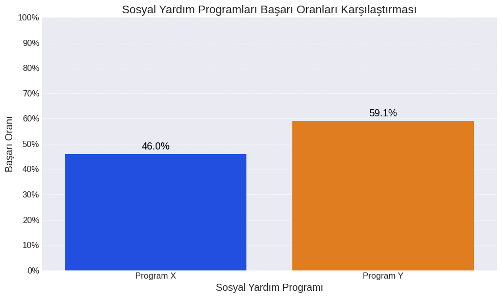

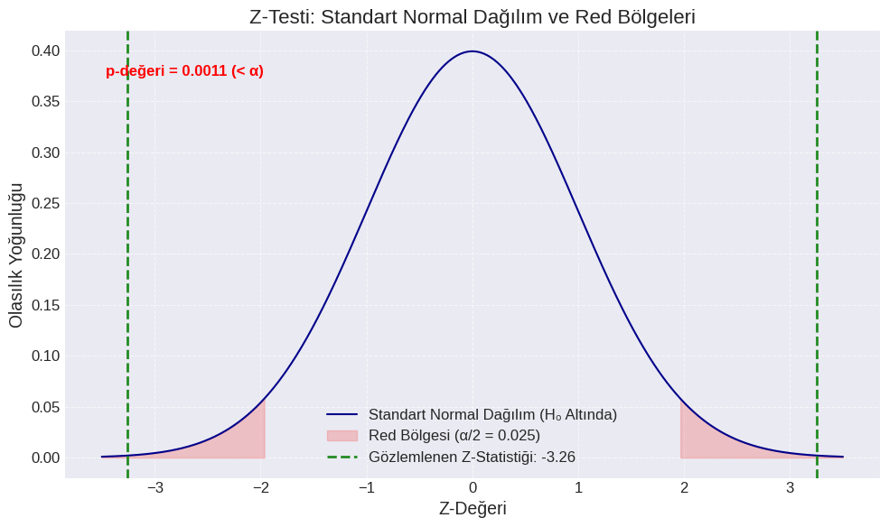

```python
# --- 5. Görselleştirme ---

# Başarı oranlarını gösteren çubuk grafik
plt.figure(figsize=(10, 6))
sns.barplot(x=['Program X', 'Program Y'], y=[p_success_x_obs, p_success_y_obs], palette='bright')

# Oran değerlerini çubukların üzerine yazma
for index, value in enumerate([p_success_x_obs, p_success_y_obs]):
    plt.text(index, value + 0.01, f'{value:.1%}', ha='center', va='bottom', fontsize=14, color='black')

plt.title('Sosyal Yardım Programları Başarı Oranları Karşılaştırması')
plt.xlabel('Sosyal Yardım Programı')
plt.ylabel('Başarı Oranı')
plt.ylim(0, 1.0)
plt.yticks(np.arange(0, 1.1, 0.1), [f'{i:.0%}' for i in np.arange(0, 1.1, 0.1)])
plt.grid(axis='y', linestyle='--', alpha=0.7)
plt.tight_layout()
plt.show()

# P-değeri ve Z-istatistiği görselleştirmesi
x = np.linspace(-3.5, 3.5, 1000) # Z-değeri aralığını duruma göre ayarladım
pdf = stats.norm.pdf(x)

plt.figure(figsize=(10, 6))
plt.plot(x, pdf, color='darkblue', label='Standart Normal Dağılım (H₀ Altında)')

# Kritik bölgeleri boyama
lower_critical = stats.norm.ppf(alpha/2)
upper_critical = stats.norm.ppf(1 - alpha/2)

x_fill_left = x[x <= lower_critical]
x_fill_right = x[x >= upper_critical]
plt.fill_between(x_fill_left, 0, stats.norm.pdf(x_fill_left), color='lightcoral', alpha=0.4, label=f'Red Bölgesi (α/2 = {alpha/2})')
plt.fill_between(x_fill_right, 0, stats.norm.pdf(x_fill_right), color='lightcoral', alpha=0.4)

# Gözlemlenen Z-istatistiğini işaretleme
plt.axvline(z_statistic, color='forestgreen', linestyle='--', linewidth=2, label=f'Gözlemlenen Z-Statistiği: {z_statistic:.2f}')
plt.axvline(-z_statistic, color='forestgreen', linestyle='--', linewidth=2) # Çift yönlü test için simetrik nokta

# P-değeri metni
if p_value < alpha:
    plt.text(0.05, 0.9, f'p-değeri = {p_value:.4f} (< α)', transform=plt.gca().transAxes,
             fontsize=12, color='red', weight='bold')
else:
    plt.text(0.05, 0.9, f'p-değeri = {p_value:.4f} (≥ α)', transform=plt.gca().transAxes,
             fontsize=12, color='darkgreen', weight='bold')

plt.title('Z-Testi: Standart Normal Dağılım ve Red Bölgeleri')
plt.xlabel('Z-Değeri')
plt.ylabel('Olasılık Yoğunluğu')
plt.legend()
plt.grid(True, linestyle='--', alpha=0.6)
plt.tight_layout()
plt.show()
```

## İş Uygulaması : Kullanıcı Arayüzü Deneyi (AB Testi)

Kullanıcı Deneyim Optimizasyonu

Problem:

Kırmızı Buton mu, Yeşil Buton mu?

Elimizde iki tane buton rengi var ve bunlardan hangisinin kullanılması gerektiğine karar vermeye çalışıyoruz.

HİPOTEZ:

Ölçümler:

Yeşil Buton - 1000 görüntülenme, 300 tıklama

Kırmızı Buton - 1100 görüntülenme, 250 tıklama

```python
from statsmodels.stats.proportion import proportions_ztest #iki oran arasında karşılaştırma yapmak için gerekli modülü import edelim
```

```python
import numpy as np
basari_sayisi=np.array([300,250])
gozlem_sayilari=np.array([1000,1100])

#iki oran arasında karşılaştırma yapmak için bu fonksiyonu kullanıyoruz, bu fonksiyonun içerisine başarı sayısı, gözlem sayısı ve karşılaştırılacak değeri giriyoruz. sol taraftaki değer test istatistiğini, sağ taraftaki değer ise p-value değerini verir
T_statistic, p_value = proportions_ztest(count=basari_sayisi,nobs=gozlem_sayilari)
print("T- Statistic:", T_statistic)
print(f"P-Value:{p_value} ,pvalue<0.05 Ho hipotezi reddedilir.Varsayım için n>30 zaten çoğu zaman 30 dan buyuktur.")
```

```
T- Statistic: 3.7857863233209255
P-Value:0.0001532232957772221 ,pvalue<0.05 Ho hipotezi reddedilir.Varsayım için n>30 zaten çoğu zaman 30 dan buyuktur.
```

Çıkan sonuç incelenecek olursa P-Value değeri 0.05'den oldukça küçük olduğundan dolayı, H0 hipotezi reddedilir.

H0: P1 = P2 iki buton arasında istatistiki olarak anlamlı bir fark yoktur diyordu.

Hazırlanan buton renkleri incelendiğinde bu butonların kullanıcı davranışlarına etkisi farklıdır. Ve bu farklılık yeşil butonun lehine olacak şekilde gerçekleşmektedir. Örnek oranının arasında istatistiki olarak anlamlı bir farklılık vardır!

Bu durumda yeşil butonu seçip, geliştirmelerimizi gerçekleştirmiş olacağız.